# Analysis of OMICS data, practical 2

IGV Tutorial

Author

Affiliation

Eszter Ari

Eötvös Loránd University, Budapest & Biological Research Centre, Szeged

Published

February 20, 2026

**The description of the practical is based on the [IGV tutorial of Alex H. Wagner](https://github.com/griffithlab/rnaseq_tutorial/wiki/IGV-Tutorial)**

# Introduction

## Description of the practical

This practical will introduce you to the [Integrative Genomics Viewer](http://software.broadinstitute.org/software/igv/), one of the most popular visualization tools for High Throughput Sequencing data.

After this practical, you will be able to:

- Visualize a variety of genomic data
- Quickly navigate around the genome
- Visualize read alignments
- Validate SNP/SNV calls and structural re-arrangements by eye

To solve the tasks may take between **1-2 hours**, depending on your familiarity with genome browsing.

The questions to answer during the practical are denoted by boxes, as follows: **Question(s):**

**NoteQ0**

Questions to solve go here.

## Compatibility

This tutorial was intended for **IGV v2.8.0**, which is available on the [IGV Download](http://software.broadinstitute.org/software/igv/download) page. It is recommended that you use this version but you can try the latest version as well.

## Data Set to Investigate with IGV

We will use publicly available Illumina sequence data from the HCC1143 cell line. The HCC1143 cell line was generated from a 52 year old Caucasian woman with breast cancer. Additional information on this cell line can be found here: [HCC1143](http://www.atcc.org/products/all/CRL-2321.aspx) (tumour, TNM stage IIA, grade 3, primary ductal carcinoma) and [HCC1143/BL](http://www.atcc.org/products/all/CRL-2362.aspx) (matched normal EBV transformed lymphoblast cell line).

Sequence read alignments generated from a cell line HCC1143 that have been filtered to this region: **Chromosome 21: 19,000,000-20,000,000**.

There are two files which we need:

- **HCC1143.normal.21.19M-20M.bam** contains the mapped reads in binary format
- **HCC1143.normal.21.19M-20M.bam.bai** the index file for the mapped reads

Create a new working directory for this practical in your *home* directory to the files of this practical (*i.e.* `02_OMICS_IGV`).

You will need the two input files above.

Link (`ln -s`) the *bam* and *bai* files from the `/shared/OMICS/practical_02` folder to your working directory.

**OR**

Download the files from the web to your working directory using the `wget` command and the following links: HCC1143.normal.21.19M-20M.bam, HCC1143.normal.21.19M-20M.bam.bai

# Visualization Part 1: Getting familiar with IGV

After logging in with **X11 forward** (*i.e.* `ssh -X`) to the server, start the **IGV software**: `igv &`.

## Get familiar with the interface

### Load a Genome and some Data Tracks

By default, **IGV** loads the Human *hg19* genome version. If you work with another version of the human genome, or another organism altogether, you can change the genome by clicking the drop down menu in the upper-left. For this practical, we will be using *Human hg19*.

We will also load additional tracks from **Server** using (`File -> Load from Server...`):

- Ensembl Genes: `Available Datasets -> Annotations -> Genes -> Ensembl Genes`
- GC Percentage: `Available Datasets -> Annotations -> Sequence and Regulation -> GC Percentage`
- dbSNP 1.4.7: `Available Datasets -> Annotations -> Variation and Repeats -> dbSNP 1.4.7`

**Load additional data tracks**

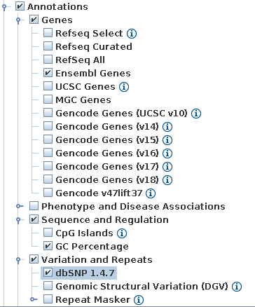

### Navigation

You should see listing of chromosomes in this reference genome. Choose **1**, for chromosome 1.

**Chromosome chooser**

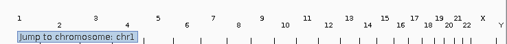

Navigate to region **chr1:10,000-11,000** by entering this into the *location* field (in the top-left corner of the interface) and clicking `Go`. This shows a window of chromosome 1 that is 1,000 base pairs wide and beginning at position 10,000.

**Navigation using Location text field. Nucleotides displayed as thin colored rectangles.**

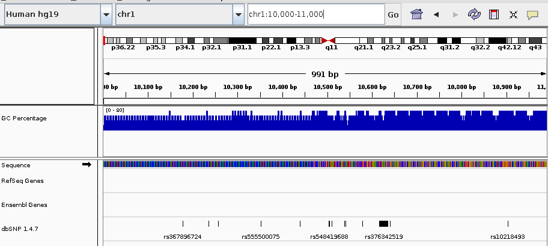

IGV displays the nucleotides in a genome as a sequence of colors (*e.g.* A = green, C = blue, *etc.*). This makes repetitive sequences, like the ones found at the start of this region, easy to identify. Zoom in a bit more using the `+` button to see the individual bases of the reference genome sequence.

You can navigate to a gene of interest by typing it in the same box the genomic coordinates are in and pressing Enter/Return. Try it for your favorite gene, or *BRCA1* if you can not decide.

**Gene model**

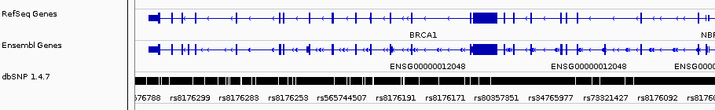

Genes are represented as lines and boxes. Lines represent intronic regions, and boxes represent exonic regions. The arrows indicate the direction/strand of transcription for the gene. When an exon box become narrower in height, this indicates a UTR.

When loaded, tracks are stacked on top of each other. You can identify which track is which by consulting the label to the left of each track.

## Region Lists

Sometimes, it is really useful to save where you are, or to load regions of interest. For this purpose, there is a **Region Navigator** in IGV. To access it, click `Regions -> Region Navigator`. While you browse around the genome, you can save some bookmarks by pressing the `Add` button at any time.

**Bookmarks in IGV**

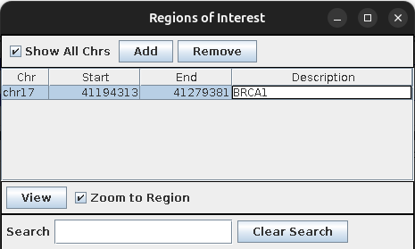

Regions of interest will be indicated with a red line at the navigation bar below the chromosome.

## Loading Read Alignments

We will be using the breast cancer cell line *HCC1143* to visualize alignments. For speed, only a small portion of chr21 will be loaded (19M:20M).

**HCC1143 Alignments to hg19:**

- HCC1143.normal.21.19M-20M.bam
- HCC1143.normal.21.19M-20M.bam.bai

Load the read alignment file from your working directory to IGV: `File -> Load from File...`, select the *bam* file, and click `OK`. Note that the *bam* and *bai* index files must be in the same directory for IGV to load these properly.

**Load bam track from File**

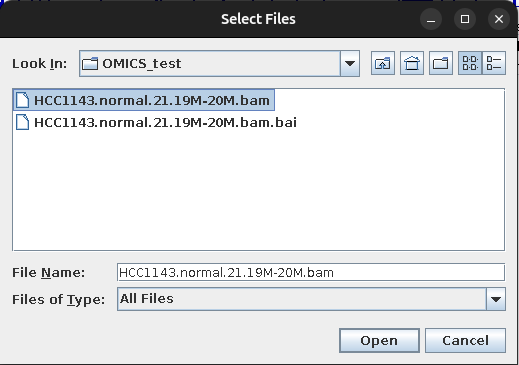

## Visualizing read alignments

Navigate to a narrow window on chromosome 21: **chr21:19,480,041-19,480,386**.

To start our exploration, *right click* on the track-name (*left bar: HCC1143.normal.21.19M-20M.bam*), and select the following options:

- Sort alignments by `start location`
- Group alignments by `pair orientation`
- Color alignments by `first-of-pair strand`

Experiment with the various settings by *right clicking* the read alignment track and toggling the options.

**Changing how read alignments are sorted, grouped, and colored**

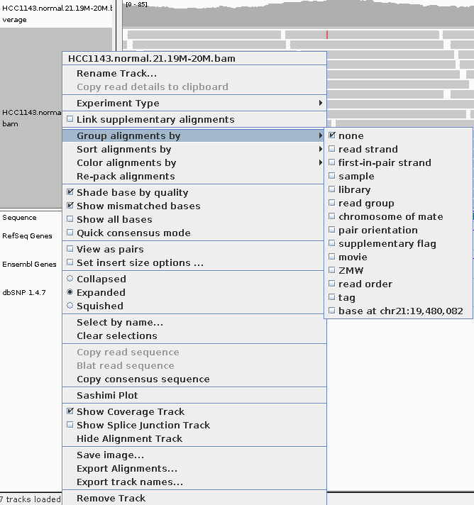

**Changing how read information is shown (*i.e.* hover, click, never)**

`Modify popup text behavior in data panels`

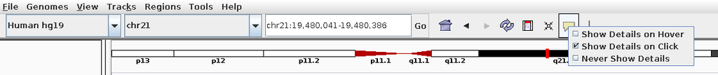

Once you select a read, you will learn what many of these metrics mean, and how to use them to assess the quality of your datasets. At each base that the read sequence **mismatches** the reference, the color of the base represents the letter that exists in the read (using the same color legend used for displaying the reference).

**Viewing read information for a single aligned read**

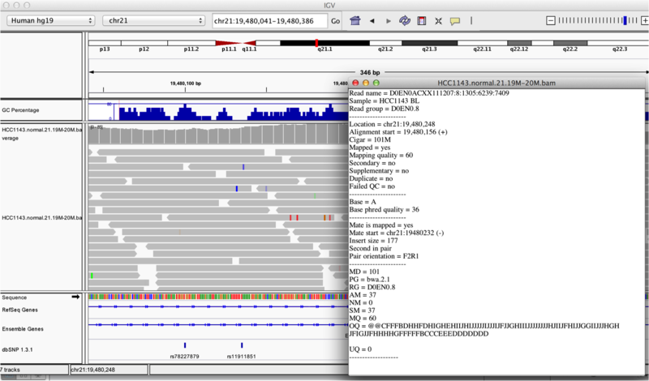

# Visualization Part 2: Inspecting SNPs, SNVs, and SVs

## Two neighboring SNPs

- Navigate to region **chr21:19,479,237-19,479,814**.
- Note **two** heterozygous variants, one corresponds to a known dbSNP (*rs982274*: **G/T** on the right) the other does not (**C/T** on the left). You can move forward and backward using the arrow button of the keyboard.
- Zoom in and center on the **C/T** SNV on the left, sort by base (window **chr21:19,479,321** is the SNV position).
- Sort alignments by *base*.

**Example1. Good quality SNVs/SNPs**

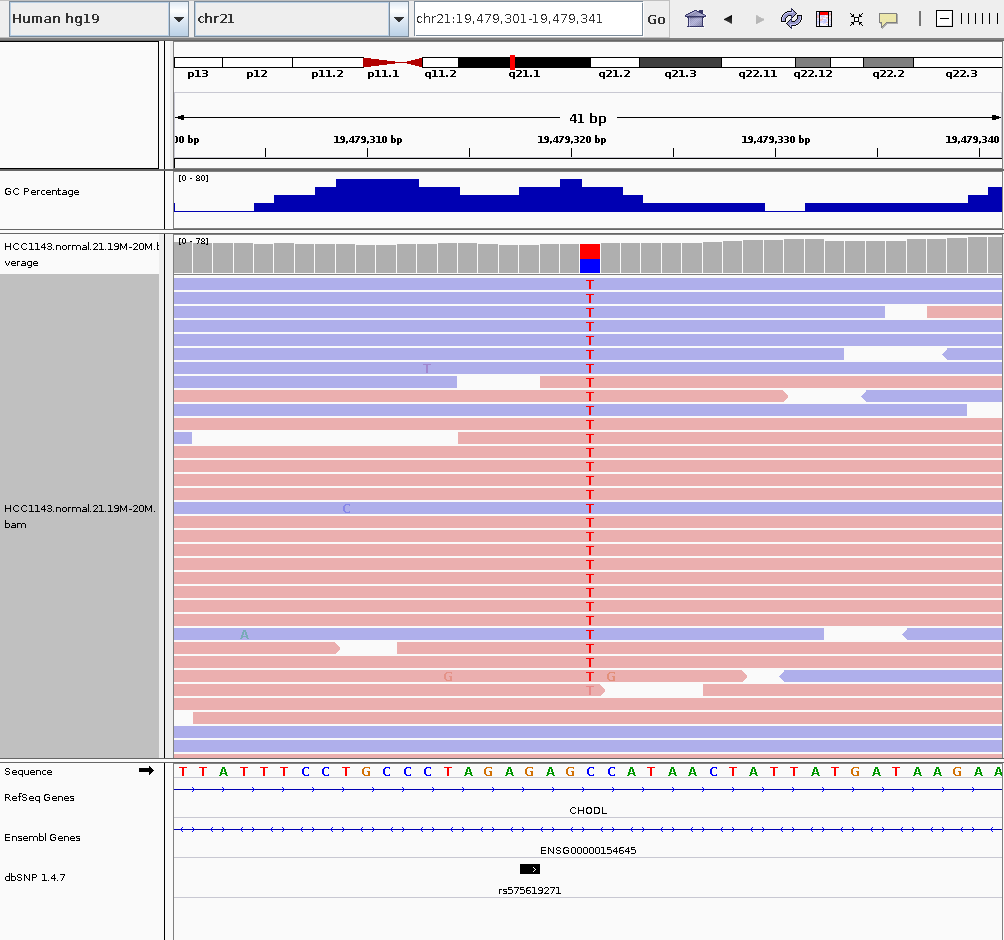

**Notes**:

- High base qualities in all reads except one (where the alternative allele is the last base of the read).
- Good mapping quality of reads, no strand bias, allele frequency consistent with heterozygous mutation.

**NoteQ1**

What does “Shade base by quality” mean? How might this be helpful?

## Homopolymer region with indel

The most abundant simple sequence repeat tracts are the *homopolymer* repeats poly(dA).poly(dT) and poly(dG).poly(dC). Long (> 9 bp) tracts of both types are found at higher than expected frequencies in the non-coding regions of eukaryote genomes. Homopolymer tracts, for example, can serve as protein binding signals, particularly as upstream promoter elements.

Navigate to position **chr21:19,518,412-19,518,497**

**Example 2a: Poor base quality in forward strand reads**

- Group alignments by *read strand*.
- Center on the **A** within the homopolymer region (**chr21:19,518,470**), and sort alignments by *base*.

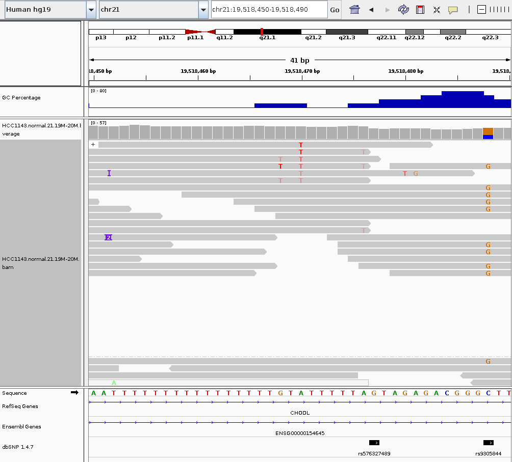

**NoteQ2**

How you can adjust the settings to emphasize that the poor base qualities are mostly found on the forward strand?

**Example 2b: Altering insertions and deletions in reverse strand reads**

- Center on the one base deletion (**chr21:19,518,452**).
- Group alignments by *none*.
- Sort alignments by *base*.
- Color alignments by *read strand*.

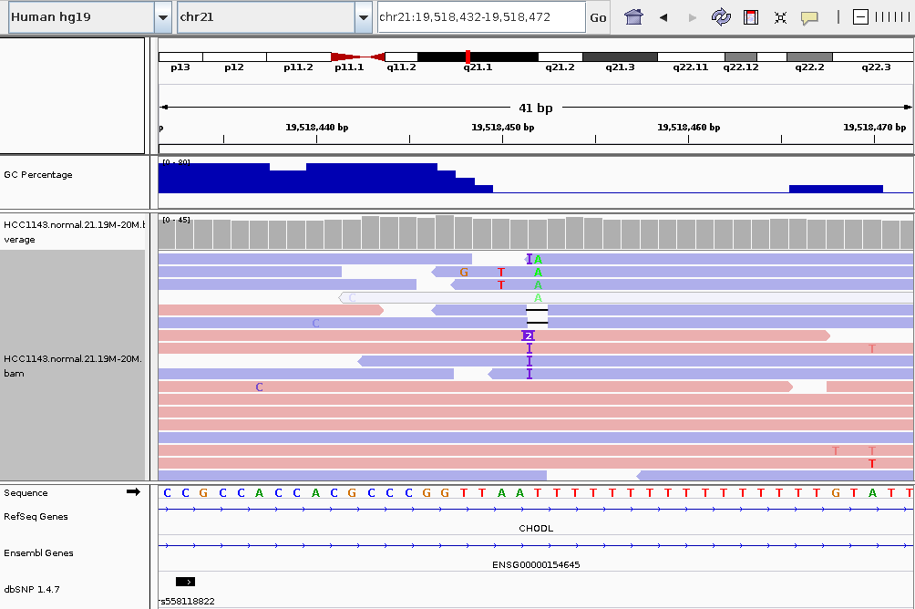

**Notes**:

- The region contains misalignments caused by repeats.
- The alternative allele is either a *deletion* or *insertion* of one or two *T*s.
- The remaining bases are mismatched, because the alignment is now out of sync.

## Coverage by GC

Navigate to position **chr21:19,611,925-19,631,555**. Note that the range contains areas where coverage drops to zero in a few places.

**Example 3**

- Use *Sqished* view.
- Color alignments by *insert size and pair orientation*.
- Take a look on *GC track*.
- See concordance of coverage with GC content.

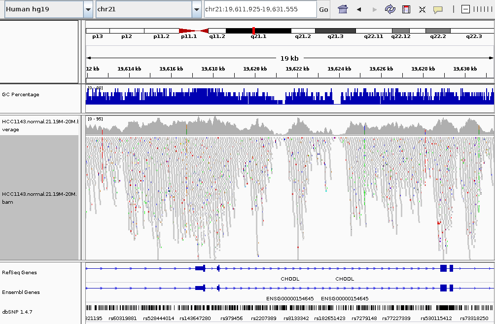

**Note**:

GC content influences the success of PCR amplification, therefore could influence coverage.

**NoteQ3**

Why are there blue and red reads throughout the alignments? (Hint: search the answern on the internet.)

## Low mapping quality

Navigate to region **chr21:19,800,320-19,818,162**

- Load repeat track (`File` -> `Load from server...`)

**Load SINE, LINE and LTR repeats**

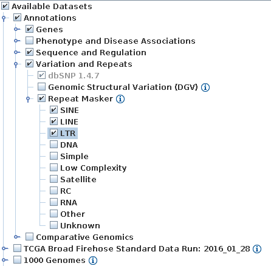

**Example 4**

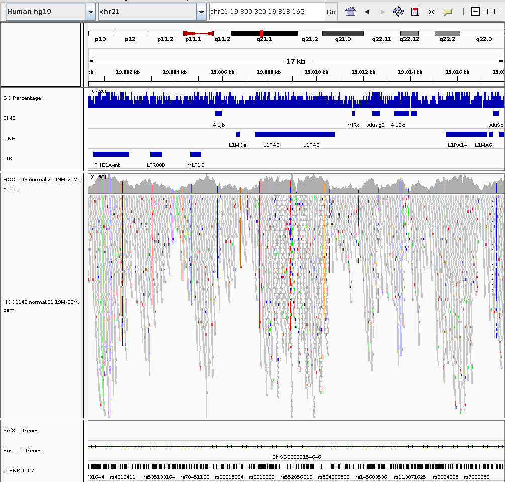

**Notes**:

- Mapping quality plunges in all reads (white instead of grey). Once we load repeat elements, we see that there are two LINE elements that cause this. [LINEs](https://en.wikipedia.org/wiki/Long_interspersed_nuclear_element) are repetitive elements in the genome.

## Homozygous deletion

Navigate to region **chr21:19,324,469-19,331,468**

**Example 5**

- Turn on *View as Pairs* and *Expanded* view.
- Color alignments by *insert size and pair orientation*.
- Sort alignments by *insert size*.
- Click on a red read pair to pull up information on alignments

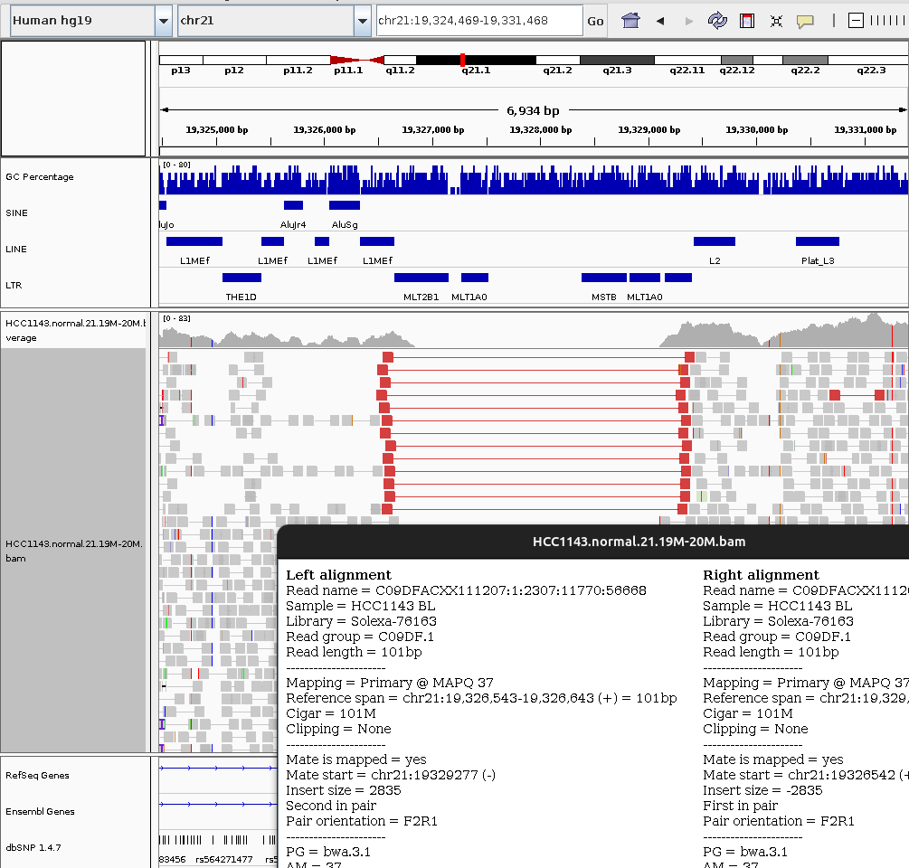

**NoteQ4**

What is the insert size of a red colored readpair?

**NoteQ5**

How long is the corresponding deletion if the insert size of other reads are 350bp?

## Translocation

Navigate to region **chr21:19,089,694-19,095,362**.

**Example 6**

- Use *expanded* view
- Group alignments by *pair orientation*.
- Color alignments by *insert size and pair orientation*.

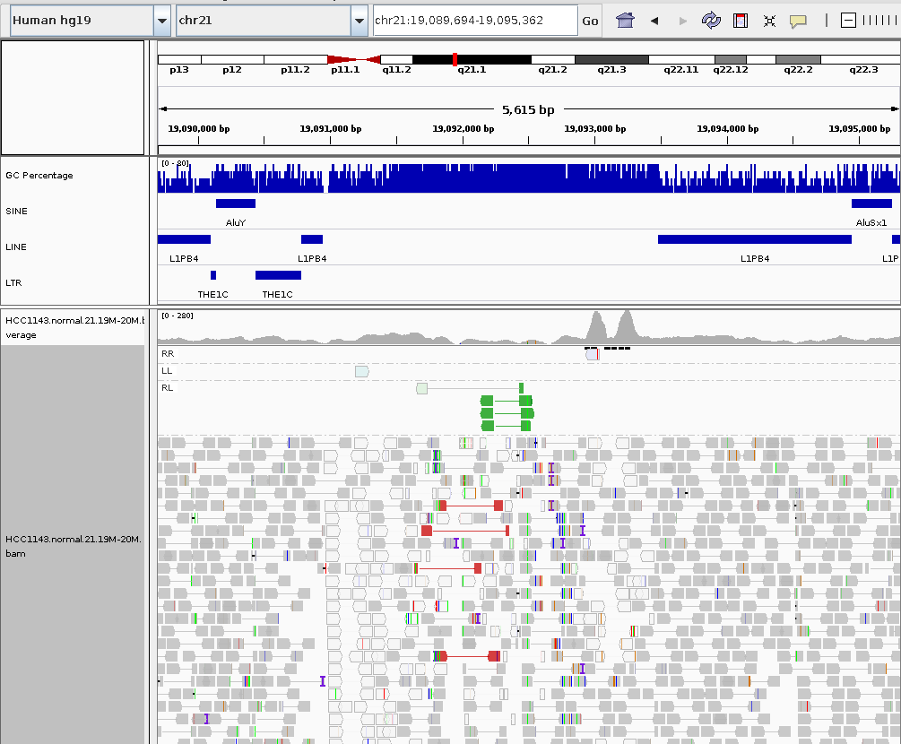

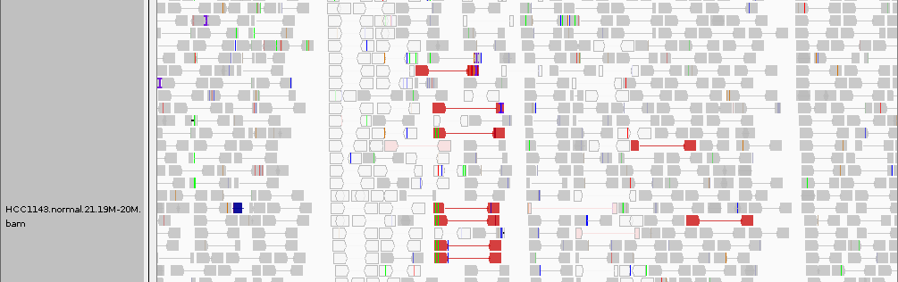

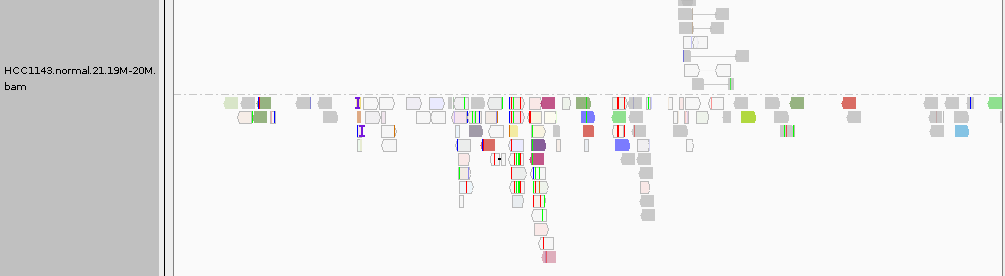

**Notes**:

- Many reads with mismatches to reference.
- Read pairs in right-left pattern (instead of left-right pattern).
- Region is flanked by reads with poor mapping quality (white instead of grey).
- Presence of reads with pairs on other chromosomes (colored reads at the bottom when scrolling down)

# Save the current session

- `File -> Save session`